# Biologia Evolutiva

Análise de Variância - ANOVA

Daniela M. Rossoni

17 de Outubro de 2018

# 1 Leitura da Aula

- [Modularity: Genes, Development, and Evolution](https://www.annualreviews.org/doi/full/10.1146/annurev-ecolsys-121415-032409) (pdf)

  **Abstract:** Modularity has emerged as a central concept for evolutionary biology, thereby providing the field with a theory of organismal structure and variation. This theory has reframed long-standing questions and serves as a unified conceptual framework for genetics, developmental biology, and multivariate evolution. Research programs in systems biology and quantitative genetics are bridging the gap between these fields. Although this synthesis is ongoing, some major themes have emerged, and empirical evidence for modularity has become abundant. In this review, we look at modularity from a historical perspective, highlighting its meaning at different levels of biological organization and the different methods that can be used to detect it. We then explore the relationship between quantitative genetic approaches to modularity and developmental genetic studies. We conclude by investigating the dynamic relationship between modularity and the adaptive landscape and how this relationship potentially shapes evolution and can help bridge the gap between micro- and macroevolution.

# 2 Objetivo

Compreender a utilização de uma Análise de Variância e o passo a passo de sua implementação.

# 3 Banco de Dados: Morcegos!

Nós coletamos em campo 90 indivíduos de morcegos e obtivemos as seguintes informações:

1. comprimento do antebraço;
2. massa corporal;
3. sexo.

A amostra coletada está dividida em três subespécies: uma que ocorre no bioma Amazônia, outra no Cerrado, e a última da Mata Atlântica.

```r
# Gerando os dados
set.seed (4)
Bats.Amazonia.machos = round (rnorm(15, 5, 1),2)
Bats.Amazonia.femeas = round (rnorm(15, 10, 1),2)
Bats.Cerrado.machos = round (rnorm(15, 25, 1),2)
Bats.Cerrado.femeas = round (rnorm(15, 30, 1),2)
Bats.MataAtlantica.machos = round (rnorm(15, 12, 1),2)
Bats.MataAtlantica.femeas = round (rnorm(15, 8, 1),2)
massa.macho = round (rnorm(45, 17, 1),2)
massa.femea = round (rnorm(45, 13, 1),2)
Bats = data.frame (c(rep("AM",30), rep("CE",30),rep("MA",30)),
                   c(Bats.Amazonia.machos, Bats.Amazonia.femeas,
                     Bats.Cerrado.machos, Bats.Cerrado.femeas,
                     Bats.MataAtlantica.machos, Bats.MataAtlantica.femeas),
                   c(massa.macho,massa.femea), c(rep(c("M","F"),  each = 15),
                    rep(c("M","F"),  each = 15), rep(c("M","F"),  each = 15)))
names(Bats) = c("subespecies", "comp_antebraco", "peso", "sexo")
```

```r
# Você pode salvar o conjunto de dados como extensão .csv para ler mais tarde
write.csv (Bats, file = "Bats.csv")
```

```r
# Se quiser abrir mais tarde a planilha salva, use a função read.csv
Bats = read.csv("Bats.csv")

# Estabelecendo os nomes das colunas (variávies)
names(Bats) = c("subespecies", "comp_antebraco", "peso", "sexo")
```

Carregando as primeiras linhas do conjunto de dados que vamos utilizar

```r
head(Bats)
```

```
##   subespecies comp_antebraco  peso sexo
## 1          AM           5.22 15.72    M
## 2          AM           4.46 16.20    M
## 3          AM           5.89 17.16    M
## 4          AM           5.60 17.61    M
## 5          AM           6.64 17.69    M
## 6          AM           5.69 16.95    M
```

Olhando a estrutura desse conjunto de dados

```r
str(Bats)
```

```
## 'data.frame':    90 obs. of  4 variables:
##  $ subespecies   : Factor w/ 3 levels "AM","CE","MA": 1 1 1 1 1 1 1 1 1 1 ...
##  $ comp_antebraco: num  5.22 4.46 5.89 5.6 6.64 5.69 3.72 4.79 6.9 6.78 ...
##  $ peso          : num  15.7 16.2 17.2 17.6 17.7 ...
##  $ sexo          : Factor w/ 2 levels "F","M": 2 2 2 2 2 2 2 2 2 2 ...
```

# 4 Explorando os dados visualmente

Note que com isso queremos inspecionar se o comprimento do antebraço varia entre as diferentes subespécies. Ou, em outras palavras, estamos nos questionando: será que há diferença entre as subspécies no que diz respeito ao comprimento de seus antebraços?

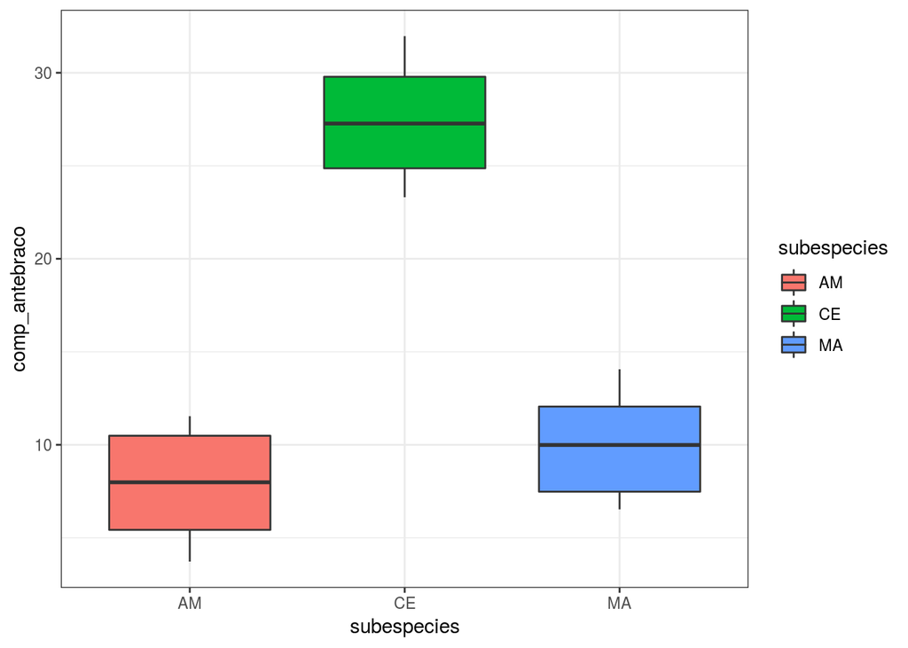

```r
if(!require(ggplot2)){install.packages("ggplot2"); library(ggplot2)}
if(!require(evolqg)){install.packages("evolqg"); library(evolqg)}
if(!require(GGally)){install.packages("GGally"); library(GGally)}
ggplot(Bats, aes(subespecies, comp_antebraco, fill = subespecies)) + theme_bw()+ geom_boxplot()
```

**Perguntas para serem discutidas a partir do gráfico acima:**

1. Quais conclusões que você obteve deste gráfico?
2. Qual é a variável dependente (resposta) e independente (preditora) avaliadas no boxplot acima?
3. Qual é a variável contínua ou quantitativa?
4. Qual é a variável categórica ou discreta?

Note que, visualmente, o boxplot indica um efeito da subespécie no comprimento do antebraço.

**Mas, será que essa diferença é real ou apenas um efeito do acaso?**

# 5 Análise de Variância passo a passo

Aqui nós vamos investigar o efeito de uma variável categórica (preditora - x) sobre a variação de uma variável contínua (resposta - y). A nossa questão é a seguinte:

**O comprimento do antebraço varia entre as diferentes subespécies de morcegos?**

Mas antes de fazermos a ANOVA descreva:

1. Qual a hipótese nula?
2. Qual a hipotése alternativa?

# 6 A Grande Média

```r
if(!require(plyr)){install.packages("plyr"); library(plyr)}

compr.antebraco = data.frame (AM = Bats[1:30,2], CE=Bats[31:60,2], MA = Bats[61:90,2])

media.compr.antebraco = apply (compr.antebraco, 2, mean)

grande.media = mean(media.compr.antebraco)
grande.media
```

```
## [1] 15.08778
```

# 7 A Soma dos Quadrados Total (SQT)

A Soma dos Quadarados Total é uma estimativa de quanto o conjunto de dados (todos os grupos) varia em relacao à grande media.

O cálculo é simples:

Temos que somar as distâncias dos dados de todos os grupos e a grande media, elevado ao quadrado.

```r
diff.total = compr.antebraco - grande.media

diff.total.quad = diff.total^2

SQT = sum(diff.total.quad)
SQT
```

```
## [1] 7541.426
```

Graus de liberdade:

```r
# número de grupos (3) vezes o número de cada grupo (30) menos 1
# (m*n)-1
# (3 * 30) - 1 = 89
```

Se nós dividirmos 7541.426 (SQT) por 89 (graus de liberdade) vamos ter a variância para toda a amostra!

Nós vimos na aula teórica sobre ANOVA que a soma dos quadrados total é igual a soma dos quadrados dentro e entre grupos:

**SQT = SQ Dentro + SQ Entre**

Nós sabemos que a variação total (SQT) é 7541.426.

Então a próxima pergunta que devemos fazer é:

**O quanto dessa variação total se refere à variação entre e dentros dos grupos?**

# 8 A Soma dos Quadrados Dentro dos Grupos (SQD)

Para obter o valor da soma dos quadrados dentro dos grupos, nós vamos somar as distâncias de cada medida de comprimento de antebraço para sua respectiva média (média de cada subespécie: AM, CE ou MA), elevado ao quadrado.

```r
compr.antebraco # data.frame com os comprimentos de antebraço para cada subespécie
```

```
##       AM    CE    MA
## 1   5.22 25.15 10.93
## 2   4.46 26.05 13.06
## 3   5.89 24.25 10.69
## 4   5.60 23.52 14.06
## 5   6.64 25.86 12.13
## 6   5.69 24.60 11.77
## 7   3.72 24.77 11.60
## 8   4.79 25.93 12.89
## 9   6.90 24.53 12.53
## 10  6.78 24.36 11.83
## 11  5.57 26.34 12.16
## 12  5.02 25.18 11.51
## 13  5.38 26.29 11.04
## 14  4.95 23.31 12.18
```

[output cut: 16 more lines]

```r
media.compr.antebraco # média do comprimento do antebraço para cada subespécie
```

```
##        AM        CE        MA
##  7.988667 27.463000  9.811667
```

```r
sq.compr.antebraco.AM = sum((compr.antebraco["AM"]-media.compr.antebraco["AM"])^2)
sq.compr.antebraco.AM
```

```
## [1] 213.3411
```

```r
sq.compr.antebraco.CE = sum((compr.antebraco["CE"]-media.compr.antebraco["CE"])^2)
sq.compr.antebraco.CE
```

```
## [1] 214.6092
```

```r
sq.compr.antebraco.MA = sum((compr.antebraco["MA"]-media.compr.antebraco["MA"])^2)
sq.compr.antebraco.MA
```

```
## [1] 172.0502
```

```r
SQD = sum(sq.compr.antebraco.AM, sq.compr.antebraco.CE, sq.compr.antebraco.MA)
SQD
```

```
## [1] 600.0006
```

```r
# Graus de liberdade:
# m(n-1) = 3(30 - 1): 3 * 29 = 87
```

# 9 Soma dos Quadrados Entre os grupos (SQE)

Vamos estimar quanto dessa variação se deve a variação entre essas médias.

Para cada medida do comprimento do antebraço, vamos calcular a distância ao quadrado entre a média da subespécie e a média das médias.

```r
media.compr.antebraco # média do comprimento dao antebraço para cada subespécie
```

```
##        AM        CE        MA
##  7.988667 27.463000  9.811667
```

```r
grande.media
```

```
## [1] 15.08778
```

```r
SQE.AM = 30*(media.compr.antebraco["AM"] - grande.media)^2

SQE.CE = 30*(media.compr.antebraco["CE"] - grande.media)^2

SQE.MA = 30*(media.compr.antebraco["MA"] - grande.media)^2

SQE = c(SQE.AM + SQE.CE + SQE.MA)
SQE
```

```
##       AM
## 6941.426
```

Ou, simplesmente:

```r
SQE_simples = sum(30*(media.compr.antebraco - grande.media)^2)

SQE_simples + SQD # veja se o total é igual ao valor de SQT
```

```
## [1] 7541.426
```

Graus de liberdade: (m-1): 2

Variação total (SQT) = variçao dentro dos grupos (SQD) + variaçao entre grupos (SQE).

Some os objetos SQD e SQE e confira o resultado com o valor do objeto SQT.

Agora, some também os graus de liberdade de SQD e SQE e veja se é igual ao valor de graus de liberdade de SQT.

# 10 Cálculo do F de Fisher

Vamos agora calcular a estatística F. Ela é definida como sendo a razão entre SQE/g.l (desvio medio) e SDQ/g.l (desvio medio).

```r
mq.entre = SQE/2

mq.dentro = SQD/87

mq.entre
```

```
##       AM
## 3470.713
```

```r
mq.dentro
```

```
## [1] 6.896559
```

```r
F.compr.antebraco = mq.entre/mq.dentro
F.compr.antebraco
```

```
##       AM
## 503.2529
```

# 11 Cálculo do P

Dica: faça uma busca no help do R para saber o que a função pf faz!

```r
p.compr.antebraco = pf (F.compr.antebraco,2, 87, lower.tail=FALSE)
p.compr.antebraco
```

```
##           AM
## 1.514857e-48
```

**Pergunta:**

Vc rejeitou ou aceitou sua hipótese nula? Subespécies diferentes de morcegos tem comprimentos de antebraço diferentes?

Agora faça novamente a anova no R. Dessa vez, use a funçao aov e depois use o summary para verificar os resultados? Não esqueça de olhar o help da função aov!

```r
test.anova = aov (Bats[,2] ~ Bats[,1])
summary(test.anova)
```

```
##             Df Sum Sq Mean Sq F value Pr(>F)
## Bats[, 1]    2   6941    3471   503.3 <2e-16 ***
## Residuals   87    600       7
## ---
## Signif. codes:  0 '***' 0.001 '**' 0.01 '*' 0.05 '.' 0.1 ' ' 1
```

**Para discussao:**

Existe um efeito do sexo tambem? Faz sentido testar o efeito de sexo separando por subespécie ou com tudo junto?